# IODS course project

Anna-Liina Olkinuora

# About the project

*Tällä kurssilla käytetään ohjelmistoja Rstudio, Github ja Github desktop. Rstudiota käytetään tilastolliseen analyysiin ja Githubia tiedostojen säilömiseen. Github desktopilla yhdistetään tietokoneen tiedostot ja säilytyspaikka Githubissa.*

https://github.com/aolkinuo/IODS-project

# Regression and model validation

```r
learning2014=read.table("data/learning2014.txt", sep = ",", header = TRUE)

str(learning2014)
```

```
## 'data.frame':    166 obs. of  7 variables:
##  $ gender  : Factor w/ 2 levels "F","M": 1 2 1 2 2 1 2 1 2 1 ...
##  $ Age     : int  53 55 49 53 49 38 50 37 37 42 ...
##  $ Attitude: int  37 31 25 35 37 38 35 29 38 21 ...
##  $ deep    : num  3.58 2.92 3.5 3.5 3.67 ...
##  $ stra    : num  3.38 2.75 3.62 3.12 3.62 ...
##  $ surf    : num  2.58 3.17 2.25 2.25 2.83 ...
##  $ Points  : int  25 12 24 10 22 21 21 31 24 26 ...
```

```r
dim(learning2014)
```

```
## [1] 166   7
```

Aineistossa on 166 havaintoyksikköä ja seitsemän muuttujaa. Muuttujat Age, Attitude, Points ovat numeerisia kokonaislukumuuttujia ja ne kertovat henkilön iän, asenteen tilastotiedettä kohtaan ja koepisteet. Ikä on laskettu syntymävuoden avulla. Muuttujat deep, stra ja surf ovat numeerisia muuttujia. Ne kertovat henkilön vastaukset syvällisiin, strategisiin ja pinnallisiin kysymyksiin. gender on luokiteltu muuttuja ja sen arvo 1 kuvaa naista ja arvo 2 miestä.

```r
summary(learning2014)
```

```
##  gender       Age           Attitude          deep            stra
##  F:110   Min.   :17.00   Min.   :14.00   Min.   :1.583   Min.   :1.250
##  M: 56   1st Qu.:21.00   1st Qu.:26.00   1st Qu.:3.333   1st Qu.:2.625
##          Median :22.00   Median :32.00   Median :3.667   Median :3.188
##          Mean   :25.51   Mean   :31.43   Mean   :3.680   Mean   :3.121
##          3rd Qu.:27.00   3rd Qu.:37.00   3rd Qu.:4.083   3rd Qu.:3.625
##          Max.   :55.00   Max.   :50.00   Max.   :4.917   Max.   :5.000
##       surf           Points
##  Min.   :1.583   Min.   : 7.00
##  1st Qu.:2.417   1st Qu.:19.00
##  Median :2.833   Median :23.00
##  Mean   :2.787   Mean   :22.72
##  3rd Qu.:3.167   3rd Qu.:27.75
##  Max.   :4.333   Max.   :33.00
```

Aineiston yhteenvedosta, joka on tämän tekstin yläpuolella nähdään muuttujien Age, Attitude, deep, stra, surf ja Points minimit, maksimit, ensimmäinen ja kolmas kvantiili, mediaani ja keskiarvo. Muuttujasta gender nähdään sen kahden arvon frekvenssit.

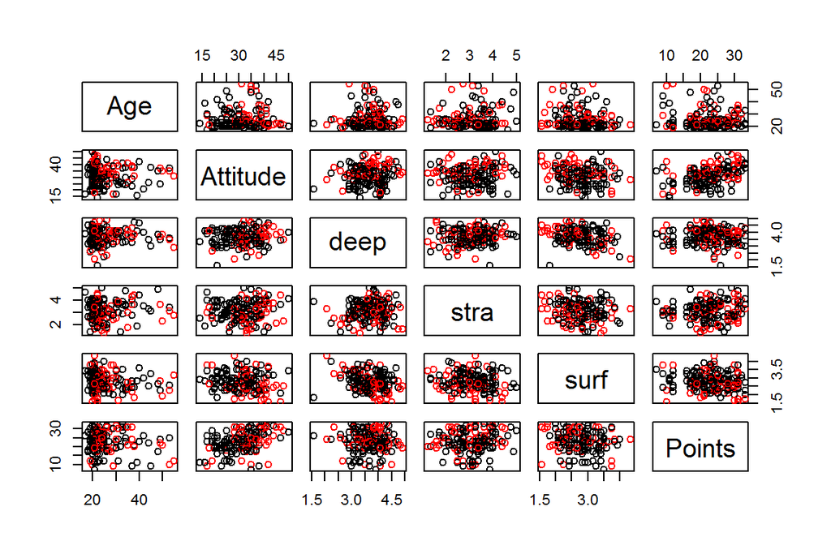

```r
library(ggplot2)

library(GGally)

pairs(learning2014[-1], col = learning2014$gender)
```

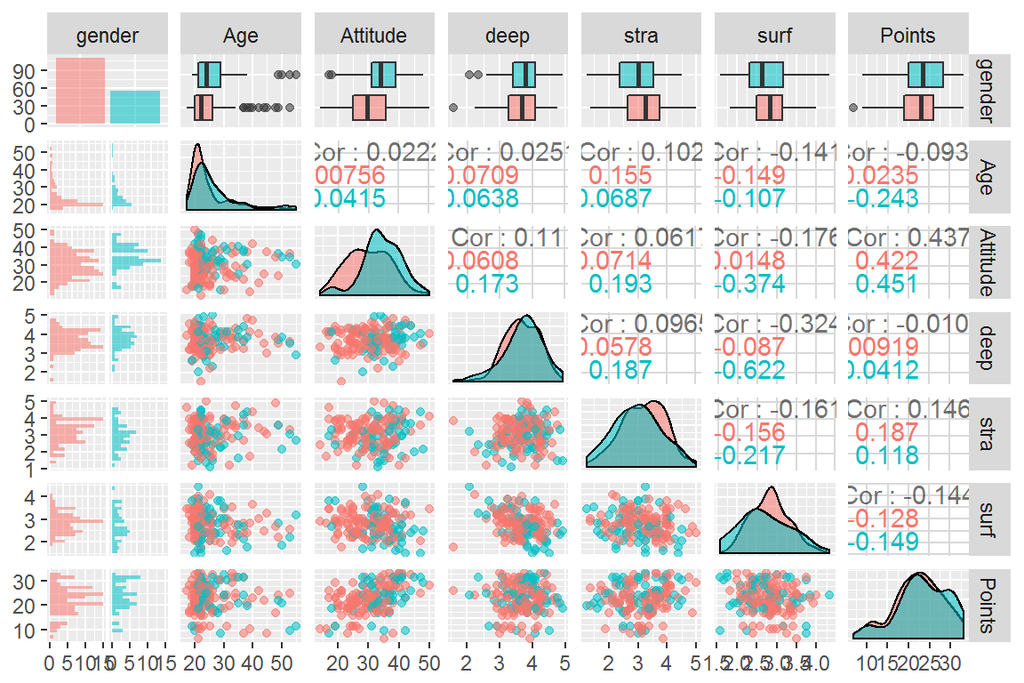

```r
p=ggpairs(learning2014, mapping = aes(col = gender, alpha = 0.3), lower = list(combo = wrap("facethist", bins = 20)))

p
```

```r
malli1=lm(Points~Age+Attitude+deep, data=learning2014)

summary(malli1)
```

```
##
## Call:
## lm(formula = Points ~ Age + Attitude + deep, data = learning2014)
##
## Residuals:
##     Min      1Q  Median      3Q     Max
## -17.206  -3.430   0.204   3.979  10.950
##
## Coefficients:
##             Estimate Std. Error t value Pr(>|t|)
## (Intercept) 15.60773    3.38966   4.605 8.32e-06 ***
## Age         -0.07716    0.05322  -1.450    0.149
## Attitude     0.35941    0.05696   6.310 2.56e-09 ***
## deep        -0.60275    0.75031  -0.803    0.423
## ---
## Signif. codes:  0 '***' 0.001 '**' 0.01 '*' 0.05 '.' 0.1 ' ' 1
##
## Residual standard error: 5.307 on 162 degrees of freedom
## Multiple R-squared:  0.2043, Adjusted R-squared:  0.1896
## F-statistic: 13.87 on 3 and 162 DF,  p-value: 4.305e-08
```

Kun estimoidaan pienimmän neliösumman menetelmällä malli jossa ikä, asenne tilastotiedettä kohtaan ja syvälliset kysymykset selittävät koepisteitä, saadaan tulokseksi tulostus joka on tämän tekstin yläpuolella.

Ensimmäisessä sarakkeessa jossa on numeroita näkyy selittäviin muuttujiin liittyvien parametrien eli parametrivektorin arvot. Niistä nähdään että kun ikä kasvaa yhdellä, koepisteet laskevat noin -0.08 verran. Kun asenne tilastotiedettä kohtaan nousee yhdellä, koepisteet kasvavat noin 0.36 verran. Kun taas syvälliset kysymykset nousevat yhdellä, koepisteet laskevat 0.6 verran. Kun ikä, asenne ja syvälliset kysymykset ovat nolla, koepisteet saavan vakiotermin mukaisen arvon eli noin 15.61.